# Lab 1 Data Visualization, Data Preprocessing, and Statistical Analysis Using Python in Jupyter Notebook

## Goutham Solasa

### Advanced Big Data and Data Mining

#### Lab 1: Data Visualization, Data Preprocessing, and Statistical Analysis Using Python in Jupyter Notebook

### Step 1: Data Collection

**Importing Libraries and Loading the Dataset**

The necessary libraries were imported to facilitate data handling, calculations and visualisation. Data was successfully loaded and the first 5 records were examined.

```python
# Importing required libraries
import pandas as pd
import numpy as np
import matplotlib.pyplot as plt
import warnings

# Suppressing warning messages
warnings.filterwarnings('ignore')

# Loading the dataset
df = pd.read_csv("E:\\SuperMarket Analysis.csv")

# Displaying the first five rows
print("First Five Rows of Dataset")
display(df.head())
```

```
First Five Rows of Dataset
```

|  | Invoice ID | Branch | City | Customer type | Gender | Product line | Unit price | Quantity | Tax 5% | Sales | Date | Time | Payment | cogs | gross margin percentage | gross income | Rating |
| --- | --- | --- | --- | --- | --- | --- | --- | --- | --- | --- | --- | --- | --- | --- | --- | --- | --- |
| 0 | 750-67-8428 | Alex | Yangon | Member | Female | Health and beauty | 74.69 | 7 | 26.1415 | 548.9715 | 1/5/2019 | 1:08:00 PM | Ewallet | 522.83 | 4.761905 | 26.1415 | 9.1 |
| 1 | 226-31-3081 | Giza | Naypyitaw | Normal | Female | Electronic accessories | 15.28 | 5 | 3.8200 | 80.2200 | 3/8/2019 | 10:29:00 AM | Cash | 76.40 | 4.761905 | 3.8200 | 9.6 |
| 2 | 631-41-3108 | Alex | Yangon | Normal | Female | Home and lifestyle | 46.33 | 7 | 16.2155 | 340.5255 | 3/3/2019 | 1:23:00 PM | Credit card | 324.31 | 4.761905 | 16.2155 | 7.4 |
| 3 | 123-19-1176 | Alex | Yangon | Member | Female | Health and beauty | 58.22 | 8 | 23.2880 | 489.0480 | 1/27/2019 | 8:33:00 PM | Ewallet | 465.76 | 4.761905 | 23.2880 | 8.4 |
| 4 | 373-73-7910 | Alex | Yangon | Member | Female | Sports and travel | 86.31 | 7 | 30.2085 | 634.3785 | 2/8/2019 | 10:37:00 AM | Ewallet | 604.17 | 4.761905 | 30.2085 | 5.3 |

**Displaying Dataset Information**

The dataset information was presented for an analysis of the missingness of data, data types, and columns. The overall dataset structure was checked before further data analysis.

```python
# Displaying dataset information
df.info()
```

```
<class 'pandas.core.frame.DataFrame'>
RangeIndex: 1000 entries, 0 to 999
Data columns (total 17 columns):
 #   Column                   Non-Null Count  Dtype
---  ------                   --------------  -----
 0   Invoice ID               1000 non-null   object
 1   Branch                   1000 non-null   object
 2   City                     1000 non-null   object
 3   Customer type            1000 non-null   object
 4   Gender                   1000 non-null   object
 5   Product line             1000 non-null   object
 6   Unit price               1000 non-null   float64
 7   Quantity                 1000 non-null   int64
 8   Tax 5%                   1000 non-null   float64
 9   Sales                    1000 non-null   float64
 10  Date                     1000 non-null   object
 11  Time                     1000 non-null   object
 12  Payment                  1000 non-null   object
 13  cogs                     1000 non-null   float64
 14  gross margin percentage  1000 non-null   float64
 15  gross income             1000 non-null   float64
 16  Rating                   1000 non-null   float64
dtypes: float64(7), int64(1), object(9)
memory usage: 132.9+ KB
```

### Step 2: Data Visualization

**Converting Date Column Format**

The Date column was changed to a date and time format for more convenient analysis. The data became suitable for performing time-based operations.

```python
# Converting date column format
df['Date'] = pd.to_datetime(df['Date'])
```

**Creating a Line Plot for Daily Total Sales**

Sales values were grouped and the total sales for each date were determined. A line graph was plotted to show the trend of sales over time.

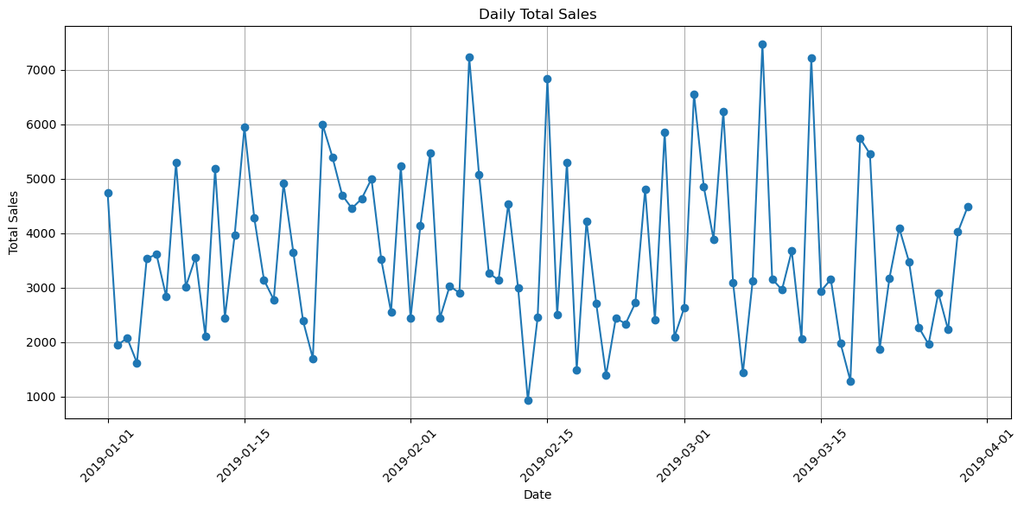

```python
# Calculating daily total sales
daily_sales = df.groupby('Date')['Sales'].sum()

# Creating figure size
plt.figure(figsize=(12,6))

# Drawing line plot
plt.plot(daily_sales.index, daily_sales.values, marker='o')

# Adding plot title
plt.title('Daily Total Sales')

# Adding horizontal label
plt.xlabel('Date')

# Adding vertical label
plt.ylabel('Total Sales')

# Rotating horizontal labels
plt.xticks(rotation=45)

# Displaying grid lines
plt.grid(True)

# Adjusting plot layout
plt.tight_layout()

# Displaying the plot
plt.show()
```

The total sales per day had some noticeable fluctuations over the period of observation, which meant that the sales performance pattern wasn't consistent from one day to the next. There were several sharp peaks that signified days with extremely high sales, and a few deep dips that signified days with lower sales activity. The sale values for most days were in a moderate range with a few extreme rises and falls. There was no discernible trend in the daily sales, indicating that the sales data for those days was not consistently increasing or decreasing.

**Creating a Bar Chart for Sales by Product Line**

The sales values were added to get the total sales for each product line. A total bar chart was produced to make comparisons between the total sales of products.

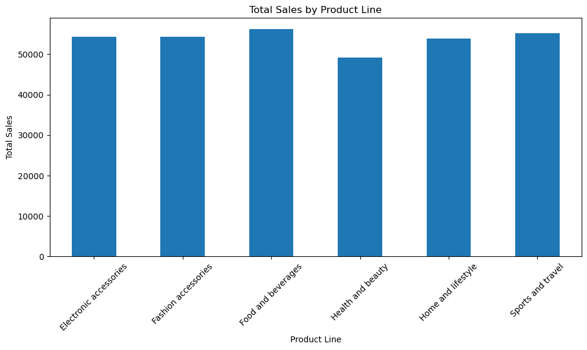

```python
# Calculating sales by product line
product_sales = df.groupby('Product line')['Sales'].sum()

# Creating figure size
plt.figure(figsize=(10,6))

# Drawing bar chart
product_sales.plot(kind='bar')

# Adding chart title
plt.title('Total Sales by Product Line')

# Adding horizontal label
plt.xlabel('Product Line')

# Adding vertical label
plt.ylabel('Total Sales')

# Rotating horizontal labels
plt.xticks(rotation=45)

# Adjusting chart layout
plt.tight_layout()

# Displaying the chart
plt.show()
```

Total sales were relatively consistent by product line, suggesting an even distribution of sales by product line. The highest total sales were in the Food and beverages category and the lowest sales were in the Health and beauty category. The sales values of electronic accessories, fashion accessories, home and lifestyle and sports and travel were similar with minimal differences. The graph showed that, overall, most product lines contributed about equally with none having a big difference in performance.

**Creating a Box Plot for Gross Income**

A box plot was used to show the gross income values. The chart identified the distribution of values and/or identified any unusual values.

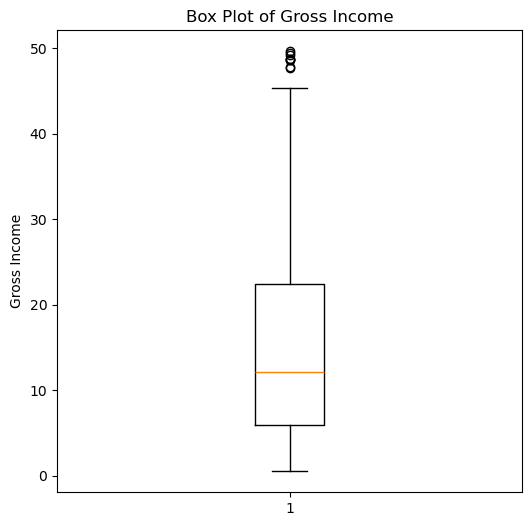

```python
# Creating figure size
plt.figure(figsize=(6,6))

# Drawing box plot
plt.boxplot(df['gross income'])

# Adding plot title
plt.title('Box Plot of Gross Income')

# Adding vertical label
plt.ylabel('Gross Income')

# Displaying the plot
plt.show()
```

**Creating a Pie Chart for Payment Method Distribution**

Data was used to calculate the number of transactions for each payment method. The information was presented in a pie chart, in which each section is a percentage of the whole.

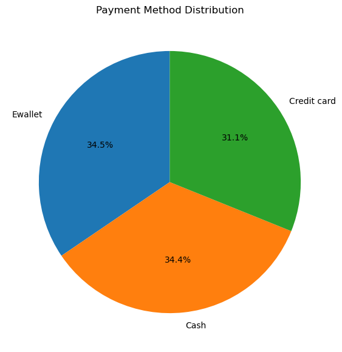

```python
# Calculating payment method counts
payment_counts = df['Payment'].value_counts()

# Creating figure size
plt.figure(figsize=(7,7))

# Drawing pie chart
plt.pie(payment_counts,
        labels=payment_counts.index,
        autopct='%1.1f%%',
        startangle=90)

# Adding chart title
plt.title('Payment Method Distribution')

# Displaying the chart
plt.show()
```

### Step 3: Data Preprocessing

#### 1. Handling Missing Values

**Detecting Missing Values**

The missing values for each column were determined and the number of missing values counted. The results were presented so that it could be identified which columns needed data cleaning.

```python
# Displaying missing values in each column
print("Missing Values in Each Column")
print(df.isnull().sum())
```

```
Missing Values in Each Column
Invoice ID                 0
Branch                     0
City                       0
Customer type              0
Gender                     0
Product line               0
Unit price                 0
Quantity                   0
Tax 5%                     0
Sales                      0
Date                       0
Time                       0
Payment                    0
cogs                       0
gross margin percentage    0
gross income               0
Rating                     0
dtype: int64
```

All the features have a count of 0 for missing values, meaning there are no missing values in the dataset. This means that there are no missing values that need to be treated or imputed to the set of data in order for them to be analyzed.

#### 2. Outlier Detection and Removal (IQR)

**Calculating Outlier Limits Using IQR**

Sales values were used to find the first quartile, third quartile and interquartile range. The lower and upper limits were then calculated to see if there were any outliers present.

```python
# Calculating first quartile
Q1 = df['Sales'].quantile(0.25)

# Calculating third quartile
Q3 = df['Sales'].quantile(0.75)

# Calculating interquartile range
IQR = Q3 - Q1

# Displaying first quartile
print("First Quartile (Q1):", Q1)

# Displaying third quartile
print("Third Quartile (Q3):", Q3)

# Displaying interquartile range
print("Interquartile Range (IQR):", IQR)

# Calculating lower limit
lower_limit = Q1 - 1.5 * IQR

# Calculating upper limit
upper_limit = Q3 + 1.5 * IQR

# Displaying lower limit
print("Lower Limit:", lower_limit)

# Displaying upper limit
print("Upper Limit:", upper_limit)
```

```
First Quartile (Q1): 124.422375
Third Quartile (Q3): 471.35024999999996
Interquartile Range (IQR): 346.927875
Lower Limit: -395.9694375
Upper Limit: 991.7420625
```

**Identifying and Removing Outliers**

The outliers were determined by comparing the sale values to the calculated limits. The results of the removal of the outliers were shown and the size of the data set before and after the removal of the outliers was displayed.

```python
# Identifying outliers
outliers = df[(df['Sales'] < lower_limit) | (df['Sales'] > upper_limit)]

# Displaying identified outliers
print("\nIdentified Outliers")
display(outliers)

# Removing outliers
no_outliers = df[(df['Sales'] >= lower_limit) &
                    (df['Sales'] <= upper_limit)]

# Displaying dataset shape before removing outliers
print("Dataset Shape Before Removing Outliers:", df.shape)

# Displaying dataset shape after removing outliers
print("Dataset Shape After Removing Outliers:", no_outliers.shape)
```

```
Identified Outliers
```

|  | Invoice ID | Branch | City | Customer type | Gender | Product line | Unit price | Quantity | Tax 5% | Sales | Date | Time | Payment | cogs | gross margin percentage | gross income | Rating |
| --- | --- | --- | --- | --- | --- | --- | --- | --- | --- | --- | --- | --- | --- | --- | --- | --- | --- |
| 166 | 234-65-2137 | Giza | Naypyitaw | Normal | Male | Home and lifestyle | 95.58 | 10 | 47.790 | 1003.590 | 2019-01-16 | 1:32:00 PM | Cash | 955.8 | 4.761905 | 47.790 | 4.8 |
| 167 | 687-47-8271 | Alex | Yangon | Normal | Male | Fashion accessories | 98.98 | 10 | 49.490 | 1039.290 | 2019-02-08 | 4:20:00 PM | Credit card | 989.8 | 4.761905 | 49.490 | 8.7 |
| 350 | 860-79-0874 | Giza | Naypyitaw | Member | Female | Fashion accessories | 99.30 | 10 | 49.650 | 1042.650 | 2019-02-15 | 2:53:00 PM | Credit card | 993.0 | 4.761905 | 49.650 | 6.6 |
| 357 | 554-42-2417 | Giza | Naypyitaw | Normal | Female | Sports and travel | 95.44 | 10 | 47.720 | 1002.120 | 2019-01-09 | 1:45:00 PM | Cash | 954.4 | 4.761905 | 47.720 | 5.2 |
| 422 | 271-88-8734 | Giza | Naypyitaw | Member | Female | Fashion accessories | 97.21 | 10 | 48.605 | 1020.705 | 2019-02-08 | 1:00:00 PM | Credit card | 972.1 | 4.761905 | 48.605 | 8.7 |
| 557 | 283-26-5248 | Giza | Naypyitaw | Member | Female | Food and beverages | 98.52 | 10 | 49.260 | 1034.460 | 2019-01-30 | 8:23:00 PM | Ewallet | 985.2 | 4.761905 | 49.260 | 4.5 |
| 699 | 751-41-9720 | Giza | Naypyitaw | Normal | Male | Home and lifestyle | 97.50 | 10 | 48.750 | 1023.750 | 2019-01-12 | 4:18:00 PM | Ewallet | 975.0 | 4.761905 | 48.750 | 8.0 |
| 792 | 744-16-7898 | Cairo | Mandalay | Normal | Female | Home and lifestyle | 97.37 | 10 | 48.685 | 1022.385 | 2019-01-15 | 1:48:00 PM | Credit card | 973.7 | 4.761905 | 48.685 | 4.9 |
| 996 | 303-96-2227 | Cairo | Mandalay | Normal | Female | Home and lifestyle | 97.38 | 10 | 48.690 | 1022.490 | 2019-03-02 | 5:16:00 PM | Ewallet | 973.8 | 4.761905 | 48.690 | 4.4 |

```
Dataset Shape Before Removing Outliers: (1000, 17)
Dataset Shape After Removing Outliers: (991, 17)
```

#### 3. Data Reduction

**Performing Data Reduction**

Before reducing, the size of the original data set was shown. A random sample 30% of the records was done and the reduced data set is shown.

```python
# Displaying original dataset shape
print("Original Dataset Shape")
print(no_outliers.shape)

# Selecting random sample
no_outliers_sample = no_outliers.sample(frac=0.30, random_state=42)

# Displaying sampled dataset shape
print("Sampled Dataset Shape")
print(no_outliers_sample.shape)

# Displaying first five sampled records
display(no_outliers_sample.head())
```

```
Original Dataset Shape
(991, 17)
Sampled Dataset Shape
(297, 17)
```

|  | Invoice ID | Branch | City | Customer type | Gender | Product line | Unit price | Quantity | Tax 5% | Sales | Date | Time | Payment | cogs | gross margin percentage | gross income | Rating |
| --- | --- | --- | --- | --- | --- | --- | --- | --- | --- | --- | --- | --- | --- | --- | --- | --- | --- |
| 215 | 802-43-8934 | Alex | Yangon | Normal | Male | Home and lifestyle | 18.28 | 1 | 0.9140 | 19.1940 | 2019-03-22 | 3:05:00 PM | Credit card | 18.28 | 4.761905 | 0.9140 | 8.3 |
| 333 | 442-48-3607 | Alex | Yangon | Member | Male | Food and beverages | 23.48 | 2 | 2.3480 | 49.3080 | 2019-03-14 | 11:21:00 AM | Credit card | 46.96 | 4.761905 | 2.3480 | 7.9 |
| 506 | 387-49-4215 | Cairo | Mandalay | Member | Female | Sports and travel | 48.50 | 3 | 7.2750 | 152.7750 | 2019-01-08 | 12:50:00 PM | Cash | 145.50 | 4.761905 | 7.2750 | 6.7 |
| 311 | 181-94-6432 | Giza | Naypyitaw | Member | Male | Fashion accessories | 69.33 | 2 | 6.9330 | 145.5930 | 2019-02-05 | 7:05:00 PM | Ewallet | 138.66 | 4.761905 | 6.9330 | 9.7 |
| 88 | 504-35-8843 | Alex | Yangon | Member | Female | Sports and travel | 42.47 | 1 | 2.1235 | 44.5935 | 2019-01-02 | 4:57:00 PM | Cash | 42.47 | 4.761905 | 2.1235 | 5.7 |

**Reducing Dataset Columns**

Some less relevant columns of the sampled data were dropped to make the number of features smaller. The updated data size and the first few records were then shown.

```python
# Removing less relevant columns
df_reduced = no_outliers_sample.drop(columns=[
    'Invoice ID',
    'gross margin percentage',
    'Tax 5%'
])

# Displaying reduced dataset shape
print("Dataset After Dropping Columns")
print(df_reduced.shape)

# Displaying first five records
display(df_reduced.head())
```

```
Dataset After Dropping Columns
(297, 14)
```

|  | Branch | City | Customer type | Gender | Product line | Unit price | Quantity | Sales | Date | Time | Payment | cogs | gross income | Rating |
| --- | --- | --- | --- | --- | --- | --- | --- | --- | --- | --- | --- | --- | --- | --- |
| 215 | Alex | Yangon | Normal | Male | Home and lifestyle | 18.28 | 1 | 19.1940 | 2019-03-22 | 3:05:00 PM | Credit card | 18.28 | 0.9140 | 8.3 |
| 333 | Alex | Yangon | Member | Male | Food and beverages | 23.48 | 2 | 49.3080 | 2019-03-14 | 11:21:00 AM | Credit card | 46.96 | 2.3480 | 7.9 |
| 506 | Cairo | Mandalay | Member | Female | Sports and travel | 48.50 | 3 | 152.7750 | 2019-01-08 | 12:50:00 PM | Cash | 145.50 | 7.2750 | 6.7 |
| 311 | Giza | Naypyitaw | Member | Male | Fashion accessories | 69.33 | 2 | 145.5930 | 2019-02-05 | 7:05:00 PM | Ewallet | 138.66 | 6.9330 | 9.7 |
| 88 | Alex | Yangon | Member | Female | Sports and travel | 42.47 | 1 | 44.5935 | 2019-01-02 | 4:57:00 PM | Cash | 42.47 | 2.1235 | 5.7 |

#### 4. Data Scaling and Discretization

**Applying Min-Max Scaling**

The selected numerical columns were prepared for scaling by creating a copy of the dataset. The values were placed in a common range by using Min-Max scaling and then shown in the original and scaled ranges.

```python
# Importing scaling library
from sklearn.preprocessing import MinMaxScaler

# Creating dataset copy
df_scaled = df_reduced.copy()

# Selecting columns for scaling
scale_columns = ['Unit price',
                 'Quantity',
                 'Sales',
                 'gross income',
                 'Rating']

# Displaying values before scaling
print("Before Scaling")
display(df_scaled[scale_columns].head())

# Creating scaler
scaler = MinMaxScaler()

# Applying Min Max scaling
df_scaled[scale_columns] = scaler.fit_transform(df_scaled[scale_columns])

# Displaying values after scaling
print("After Min Max Scaling")
display(df_scaled[scale_columns].head())
```

```
Before Scaling
```

|  | Unit price | Quantity | Sales | gross income | Rating |
| --- | --- | --- | --- | --- | --- |
| 215 | 18.28 | 1 | 19.1940 | 0.9140 | 8.3 |
| 333 | 23.48 | 2 | 49.3080 | 2.3480 | 7.9 |
| 506 | 48.50 | 3 | 152.7750 | 7.2750 | 6.7 |
| 311 | 69.33 | 2 | 145.5930 | 6.9330 | 9.7 |
| 88 | 42.47 | 1 | 44.5935 | 2.1235 | 5.7 |

```
After Min Max Scaling
```

|  | Unit price | Quantity | Sales | gross income | Rating |
| --- | --- | --- | --- | --- | --- |
| 215 | 0.086786 | 0.000000 | 0.006421 | 0.006421 | 0.716667 |
| 333 | 0.145017 | 0.111111 | 0.038503 | 0.038503 | 0.650000 |
| 506 | 0.425196 | 0.222222 | 0.148731 | 0.148731 | 0.450000 |
| 311 | 0.658455 | 0.111111 | 0.141080 | 0.141080 | 0.950000 |
| 88 | 0.357671 | 0.000000 | 0.033480 | 0.033480 | 0.283333 |

**Performing Rating Discretization**

The rating values were classified into low, medium, and high ranges. The rating values and the categories were then presented for review.

```python
# Creating rating categories
df_scaled['Rating Category'] = pd.cut(
    df['Rating'],
    bins=[0,5,7,10],
    labels=['Low','Medium','High']
)

# Displaying dataset after discretization
print("Dataset After Discretization")
display(df_scaled[['Rating','Rating Category']].head(15))
```

```
Dataset After Discretization
```

|  | Rating | Rating Category |
| --- | --- | --- |
| 215 | 0.716667 | High |
| 333 | 0.650000 | High |
| 506 | 0.450000 | Medium |
| 311 | 0.950000 | High |
| 88 | 0.283333 | Medium |
| 540 | 0.850000 | High |
| 282 | 0.416667 | Medium |
| 107 | 0.566667 | High |
| 59 | 0.883333 | High |
| 511 | 0.350000 | Medium |
| 363 | 0.533333 | High |
| 450 | 0.450000 | Medium |
| 70 | 0.933333 | High |
| 96 | 0.183333 | Medium |
| 866 | 0.416667 | Medium |

### Step 4: Statistical Analysis

#### 1. General Overview of Data

**Displaying General Dataset Information**

The overall dataset information was presented to investigate the structure of the data and the data types. The summary also proved useful for determining the available columns and missing values.

```python
# Displaying dataset information
print("Dataset Information")
df.info()
```

```
Dataset Information
<class 'pandas.core.frame.DataFrame'>
RangeIndex: 1000 entries, 0 to 999
Data columns (total 17 columns):
 #   Column                   Non-Null Count  Dtype
---  ------                   --------------  -----
 0   Invoice ID               1000 non-null   object
 1   Branch                   1000 non-null   object
 2   City                     1000 non-null   object
 3   Customer type            1000 non-null   object
 4   Gender                   1000 non-null   object
 5   Product line             1000 non-null   object
 6   Unit price               1000 non-null   float64
 7   Quantity                 1000 non-null   int64
 8   Tax 5%                   1000 non-null   float64
 9   Sales                    1000 non-null   float64
 10  Date                     1000 non-null   datetime64[ns]
 11  Time                     1000 non-null   object
 12  Payment                  1000 non-null   object
 13  cogs                     1000 non-null   float64
 14  gross margin percentage  1000 non-null   float64
 15  gross income             1000 non-null   float64
 16  Rating                   1000 non-null   float64
dtypes: datetime64[ns](1), float64(7), int64(1), object(8)
memory usage: 132.9+ KB
```

**Displaying Statistical Summary**

The statistical summary of the numerical columns was presented to give an overview of the distribution of the data. Items summarized were: count, minimum, maximum, average and spread of values.

```python
# Displaying statistical summary
print("\nStatistical Summary")
display(df.describe())
```

```
Statistical Summary
```

|  | Unit price | Quantity | Tax 5% | Sales | Date | cogs | gross margin percentage | gross income | Rating |
| --- | --- | --- | --- | --- | --- | --- | --- | --- | --- |
| count | 1000.000000 | 1000.000000 | 1000.000000 | 1000.000000 | 1000 | 1000.00000 | 1.000000e+03 | 1000.000000 | 1000.00000 |
| mean | 55.672130 | 5.510000 | 15.379369 | 322.966749 | 2019-02-14 00:05:45.600000 | 307.58738 | 4.761905e+00 | 15.379369 | 6.97270 |
| min | 10.080000 | 1.000000 | 0.508500 | 10.678500 | 2019-01-01 00:00:00 | 10.17000 | 4.761905e+00 | 0.508500 | 4.00000 |
| 25% | 32.875000 | 3.000000 | 5.924875 | 124.422375 | 2019-01-24 00:00:00 | 118.49750 | 4.761905e+00 | 5.924875 | 5.50000 |
| 50% | 55.230000 | 5.000000 | 12.088000 | 253.848000 | 2019-02-13 00:00:00 | 241.76000 | 4.761905e+00 | 12.088000 | 7.00000 |
| 75% | 77.935000 | 8.000000 | 22.445250 | 471.350250 | 2019-03-08 00:00:00 | 448.90500 | 4.761905e+00 | 22.445250 | 8.50000 |
| max | 99.960000 | 10.000000 | 49.650000 | 1042.650000 | 2019-03-30 00:00:00 | 993.00000 | 4.761905e+00 | 49.650000 | 10.00000 |
| std | 26.494628 | 2.923431 | 11.708825 | 245.885335 | NaN | 234.17651 | 6.131498e-14 | 11.708825 | 1.71858 |

#### 2. Central Tendency Measures

**Calculating Central Tendency Measures**

The numerical columns were chosen for computing the primary measures of central tendency. The minimum value, maximum value, mean, median and mode were determined and presented in a summary table.

```python
# Selecting numerical columns
numeric_columns = df.select_dtypes(include=['int64', 'float64'])

# Calculating central tendency measures
central_tendency = pd.DataFrame({
    'Minimum': numeric_columns.min(),
    'Maximum': numeric_columns.max(),
    'Mean': numeric_columns.mean(),
    'Median': numeric_columns.median(),
    'Mode': numeric_columns.mode().iloc[0]
})

# Displaying central tendency measures
print("Central Tendency Measures")
display(central_tendency)
```

```
Central Tendency Measures
```

|  | Minimum | Maximum | Mean | Median | Mode |
| --- | --- | --- | --- | --- | --- |
| Unit price | 10.080000 | 99.960000 | 55.672130 | 55.230000 | 83.770000 |
| Quantity | 1.000000 | 10.000000 | 5.510000 | 5.000000 | 10.000000 |
| Tax 5% | 0.508500 | 49.650000 | 15.379369 | 12.088000 | 4.154000 |
| Sales | 10.678500 | 1042.650000 | 322.966749 | 253.848000 | 87.234000 |
| cogs | 10.170000 | 993.000000 | 307.587380 | 241.760000 | 83.080000 |
| gross margin percentage | 4.761905 | 4.761905 | 4.761905 | 4.761905 | 4.761905 |
| gross income | 0.508500 | 49.650000 | 15.379369 | 12.088000 | 4.154000 |
| Rating | 4.000000 | 10.000000 | 6.972700 | 7.000000 | 6.000000 |

#### 3. Dispersion Measures

**Calculating Dispersion Measures**

The columns containing numbers were analyzed to determine the dispersion of the values. The ranges, quartiles and interquartiles, variance and standard deviation were obtained and presented.

```python
# Calculating dispersion measures
dispersion = pd.DataFrame({
    'Range': numeric_columns.max() - numeric_columns.min(),
    'Q1': numeric_columns.quantile(0.25),
    'Q3': numeric_columns.quantile(0.75),
    'IQR': numeric_columns.quantile(0.75) - numeric_columns.quantile(0.25),
    'Variance': numeric_columns.var(),
    'Standard Deviation': numeric_columns.std()
})

# Displaying dispersion measures
print("Dispersion Measures")
display(dispersion)
```

```
Dispersion Measures
```

|  | Range | Q1 | Q3 | IQR | Variance | Standard Deviation |
| --- | --- | --- | --- | --- | --- | --- |
| Unit price | 89.8800 | 32.875000 | 77.935000 | 45.060000 | 7.019653e+02 | 2.649463e+01 |
| Quantity | 9.0000 | 3.000000 | 8.000000 | 5.000000 | 8.546446e+00 | 2.923431e+00 |
| Tax 5% | 49.1415 | 5.924875 | 22.445250 | 16.520375 | 1.370966e+02 | 1.170883e+01 |
| Sales | 1031.9715 | 124.422375 | 471.350250 | 346.927875 | 6.045960e+04 | 2.458853e+02 |
| cogs | 982.8300 | 118.497500 | 448.905000 | 330.407500 | 5.483864e+04 | 2.341765e+02 |
| gross margin percentage | 0.0000 | 4.761905 | 4.761905 | 0.000000 | 3.759526e-27 | 6.131498e-14 |
| gross income | 49.1415 | 5.924875 | 22.445250 | 16.520375 | 1.370966e+02 | 1.170883e+01 |
| Rating | 6.0000 | 5.500000 | 8.500000 | 3.000000 | 2.953518e+00 | 1.718580e+00 |

#### 4. Correlation Analysis

**Performing Correlation Analysis**

The correlation values were used to measure the relationships among the numerical columns. The correlation matrix was calculated and displayed for comparison of the variables.

```python
# Calculating correlation matrix
correlation_matrix = numeric_columns.corr()

# Displaying correlation matrix
print("Correlation Matrix")
display(correlation_matrix)
```

```
Correlation Matrix
```

|  | Unit price | Quantity | Tax 5% | Sales | cogs | gross margin percentage | gross income | Rating |
| --- | --- | --- | --- | --- | --- | --- | --- | --- |
| Unit price | 1.000000 | 0.010778 | 0.633962 | 0.633962 | 0.633962 | NaN | 0.633962 | -0.008778 |
| Quantity | 0.010778 | 1.000000 | 0.705510 | 0.705510 | 0.705510 | NaN | 0.705510 | -0.015815 |
| Tax 5% | 0.633962 | 0.705510 | 1.000000 | 1.000000 | 1.000000 | NaN | 1.000000 | -0.036442 |
| Sales | 0.633962 | 0.705510 | 1.000000 | 1.000000 | 1.000000 | NaN | 1.000000 | -0.036442 |
| cogs | 0.633962 | 0.705510 | 1.000000 | 1.000000 | 1.000000 | NaN | 1.000000 | -0.036442 |
| gross margin percentage | NaN | NaN | NaN | NaN | NaN | NaN | NaN | NaN |
| gross income | 0.633962 | 0.705510 | 1.000000 | 1.000000 | 1.000000 | NaN | 1.000000 | -0.036442 |
| Rating | -0.008778 | -0.015815 | -0.036442 | -0.036442 | -0.036442 | NaN | -0.036442 | 1.000000 |